# 10 Point Pattern Analysis II

# Point Pattern Analysis II

*NOTE*: You can download the source files for this book from [here](https://github.com/paezha/Spatial-Statistics-Course). The source files are in the format of R Notebooks. Notebooks are pretty neat, because the allow you execute code within the notebook, so that you can work interactively with the notes.

In the last practice/session your learning objectives included:

1. A formal definition of point pattern.
2. Processes and point patterns.
3. The concepts of intensity and density.
4. The concept of quadrats and how to create density maps.
5. More ways to control the look of your plots, in particular faceting and adding lines.

Please review the previous practices if you need a refresher on these concepts.

If you wish to work interactively with this chapter you will need the following:

- An R markdown notebook version of this document (the source file).
- A package called `geog4ga3`.

## Learning Objectives

In this practice, you will learn:

1. The intuition behind the quadrat-based test of independence.
2. About the limitations of quadrat-based analysis.
3. The concept of kernel density.
4. More ways to manipulate objects to do point pattern analysis using `spatstat`.

## Suggested Readings

- Bailey TC and Gatrell AC [-@Bailey1995] Interactive Spatial Data Analysis, Chapter 3. Longman: Essex.
- Baddeley A, Rubak E, Turner R [-@Baddeley2015] Spatial Point Pattern: Methodology and Applications with R, Chapter 6. CRC: Boca Raton.
- Bivand RS, Pebesma E, Gomez-Rubio V [-@Bivand2008] Applied Spatial Data Analysis with R, Chapter 7. Springer: New York.
- Brunsdon C and Comber L [-@Brunsdon2015R] An Introduction to R for Spatial Analysis and Mapping, Chapter 6, 6.1 - 6.6. Sage: Los Angeles.
- O’Sullivan D and Unwin D [-@Osullivan2010] Geographic Information Analysis, 2nd Edition, Chapter 5. John Wiley & Sons: New Jersey.

## Preliminaries

As usual, it is good practice to clear the working space to make sure that you do not have extraneous items there when you begin your work. The command in R to clear the workspace is `rm` (for “remove”), followed by a list of items to be removed. To clear the workspace from *all* objects, do the following:

```r
#clear workspace
rm(list = ls())
```

Note that `ls()` lists all objects currently on the worspace.

Load the libraries you will use in this activity:

```r
#load packages from R database

library(tidyverse)
library(spatstat)
library(geog4ga3)
```

Load the datasets that you will use for this practice:

```r
#This loads datasets from "geog4ga3" into your environment

data("PointPatterns")
data("pp0_df")
```

`PointPatterns` is a dataframe with four sets of spatial events, labeled as “Pattern 1”, “Pattern 2”, “Pattern 3”, and “Pattern 4”. Each set has $n=60$ events. You can check the class of this object by means of the function class `class()`.

```r
class(PointPatterns)
```

```
[1] "data.frame"
```

The second dataframe (i.e., `pp0_df`) includes the coordinates `x` and `y` of two sets of spatial events, labeled as “Pattern 1” and “Pattern 2”.

The summary for `PointPatterns` shows that these point patterns are located in a square-unit window (check the max and min values of x and y):

```r
summary(PointPatterns)
```

```
       x                y                 Pattern
 Min.   :0.0169   Min.   :0.005306   Pattern 1:60
 1st Qu.:0.2731   1st Qu.:0.289020   Pattern 2:60
 Median :0.4854   Median :0.550000   Pattern 3:60
 Mean   :0.5074   Mean   :0.538733   Pattern 4:60
 3rd Qu.:0.7616   3rd Qu.:0.797850
 Max.   :0.9990   Max.   :0.999808
```

The same is true for `pp0_df`:

```r
#summarizes information from the dataframe in a table

summary(pp0_df)
```

```
       x                y                 marks
 Min.   :0.0456   Min.   :0.03409   Pattern 1:36
 1st Qu.:0.2251   1st Qu.:0.22963   Pattern 2:36
 Median :0.4282   Median :0.43363
 Mean   :0.4916   Mean   :0.47952
 3rd Qu.:0.7812   3rd Qu.:0.77562
 Max.   :0.9564   Max.   :0.94492
```

As seen in the previous practice and activity, the package `spatstat` employs a type of object called `ppp` (for *p*lanar *p*oint *p*attern). Fortunately, it is relatively simple to convert a dataframe into a `ppp` object by means of `as.ppp()`. This function requires that you define a window for the point pattern, something we can do by means of the `owin` function:

```r
#"W" will appear in your environment as a defined window with boundaries of (1,1)

W <- owin(xrange = c(0, 1), yrange = c(0, 1))
```

Then the dataframes are converted using the `as.ppp` function:

```r
pp0.ppp <- as.ppp(pp0_df, W = W)
PointPatterns.ppp <- as.ppp(PointPatterns, W = W)
```

You can verify that the new objects are indeed of `ppp`-class:

```r
class(pp0.ppp)
```

```
[1] "ppp"
```

```r
class(PointPatterns.ppp)
```

```
[1] "ppp"
```

## A Quadrat-based Test for Spatial Independence

In the preceding activity, you used a quadrat-based spatial independence test to help you decide whether a pattern was random (the function was `quadrat.test`). We will now review the intuition of the test.

Let’s begin by plotting the patterns. You can use `split` to do plots for each pattern separately, instead of putting all of them in a single plot (these plots are not as responsive as `ggplot2` but are quick):

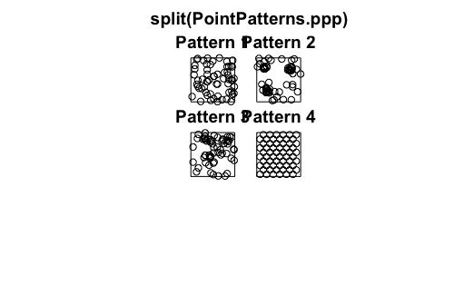

```r
#The split functions separates without deifining a window. This is a quicker option to get relative results

plot(split(PointPatterns.ppp))
```

Recall that you can also plot individual patterns by using `$` followed by the factor that identifies the desired pattern (this is a way of indexing different patterns in `ppp`-class objects):

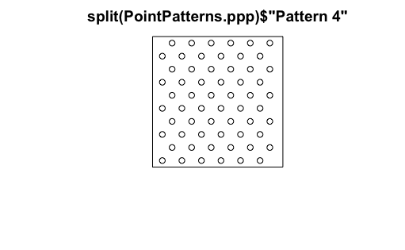

```r
#Using "$" acts as a call sign to retrive information from a data frame. In this case, you are calling "Pattern 4" from "PointPatterns.ppp"
plot(split(PointPatterns.ppp)$"Pattern 4")
```

Now calculate the quadrat-based test of independence:

```r
q_test <- quadrat.test(split(PointPatterns.ppp)$"Pattern 2", nx = 3, ny = 3)
q_test
```

```
    Chi-squared test of CSR using quadrat counts
    Pearson X2 statistic

data:  split(PointPatterns.ppp)$"Pattern 2"
X2 = 48, df = 8, p-value = 1.976e-07
alternative hypothesis: two.sided

Quadrats: 3 by 3 grid of tiles
```

Plot the results of the quadrat test:

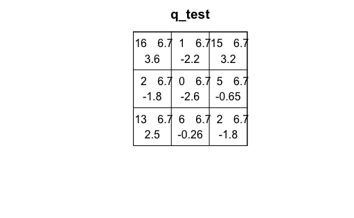

```r
plot(q_test)
```

As seen in the preceding chapter, the expected distribution of events on quadrats under the null landscape tends to be quite even. This is because each quadrat has equal probability of having the same number of events (depending on size, when the quadrats are not all the same size).

If you check the plot of the quadrat test above, you will notice that the first number (top left corner) is the number of events in the quadrat. The second number (top right corner) is the *expected number of events* for a null landscape. The third number is a *residual*, based on the difference between the observed and expected number of events.

More specifically, the residual is a *Pearson residual*, defined as follows:
$$r_i=\frac{O_i - E_i}{\sqrt{E_i}},$$
where $O_i$ is the number of observed events in quadrat $i$ and $E_i$ is the number of expected events in quadrat $i$.

When the number of observed events is similar to the number of expected events, $r_i$ will tend to be a small value. As the difference grows, the residual will also grow.

The independence test is calculated from the residuals as:
$$X2=\sum_{i=1}^{Q}r_i^2,$$
where $Q$ is the number of quadrats. In other words, the test is based on the squared sum of the Pearson residuals. The smaller this number is, the more likely that it is not different from the null landscape (i.e., a random process), and the larger it is, the more likely that it is different from the null landscape. This is reflected by the p-value of the test (technically, the p-value is obtained from comparing the test to the Chi-square distribution).

Consider for instance the first pattern in the examples:

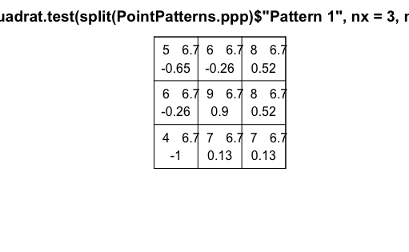

```r
plot(quadrat.test(split(PointPatterns.ppp)$"Pattern 1", nx = 3, ny = 3))
```

```r
paste("X2 = ", (-0.65)^2 + (-0.26)^2 + (0.52)^2 + (-0.26)^2 + (0.9)^2 + (0.52)^2 + (-1)^2 + (0.13)^2 + (0.13)^2)
```

```
[1] "X2 =  2.9423"
```

Which you can confirm by examining the results of the test (the small difference is due to rounding errors):

```r
quadrat.test(split(PointPatterns.ppp)$"Pattern 1", nx = 3, ny = 3)
```

```
    Chi-squared test of CSR using quadrat counts
    Pearson X2 statistic

data:  split(PointPatterns.ppp)$"Pattern 1"
X2 = 3, df = 8, p-value = 0.1313
alternative hypothesis: two.sided

Quadrats: 3 by 3 grid of tiles
```

Explore the remaining patterns. You will notice that the residuals and test statistic tend to grow as more events are concentrated in space. In this way, the test is a test of density of the quadrats: is their density similar to what would be expected from a null landscape?

## Limitations of Quadrat Analysis: Size and Number of Quadrats

As hinted by the previous activity, one issue with quadrat analysis is the selection of the size for the quadrats. Changing the size of the quadrats has an impact on the counts, and in turn on the aspect of density plots and even the results of the test of independence.

For example, the results of the test for “Pattern 2” in the dataset change when the number of quadrats is modified. For instance, with a small number of quadrats:

```r
quadrat.test(split(PointPatterns.ppp)$"Pattern 2", nx = 2, ny = 1)
```

```
    Chi-squared test of CSR using quadrat counts
    Pearson X2 statistic

data:  split(PointPatterns.ppp)$"Pattern 2"
X2 = 1.6667, df = 1, p-value = 0.3934
alternative hypothesis: two.sided

Quadrats: 2 by 1 grid of tiles
```

Compare to four quadrats:

```r
quadrat.test(split(PointPatterns.ppp)$"Pattern 2", nx = 2, ny = 2)
```

```
    Chi-squared test of CSR using quadrat counts
    Pearson X2 statistic

data:  split(PointPatterns.ppp)$"Pattern 2"
X2 = 6, df = 3, p-value = 0.2232
alternative hypothesis: two.sided

Quadrats: 2 by 2 grid of tiles
```

Why is the statistic generally smaller when there are fewer quadrats?

A different issue emerges when the number of quadrats is large:

```r
quadrat.test(split(PointPatterns.ppp)$"Pattern 2", nx = 4, ny = 4)
```

```
Some expected counts are small; chi^2 approximation may be inaccurate
```

```
    Chi-squared test of CSR using quadrat counts
    Pearson X2 statistic

data:  split(PointPatterns.ppp)$"Pattern 2"
X2 = 47.2, df = 15, p-value = 6.84e-05
alternative hypothesis: two.sided

Quadrats: 4 by 4 grid of tiles
```

A warning now tells you that some expected counts are small: space has been divided so minutely, that the expected number of events per quadrat has become too thin; as a consequence, the approximation to the probability distribution may be inaccurate.

While there are no hard rules to select the size/number of quadrats, the following rules of thumb are sometimes suggested:

1. Each quadrat should have a minimum of two events.
2. The number of quadrats is selected based on the area (A) of the region, and the number of events (n):
   $$Q=\frac{2A}{N}$$
   Caution should be exercised when interpreting the results of the analysis based on quadrats, due to the issue of size/number of quadrats.

## Limitations of Quadrat Analysis: Relative Position of Events

Another issue with quadrat analysis is its insensibility to the relative position of the events within the quadrats.

Consider for instance the following two patterns in `pp0`:

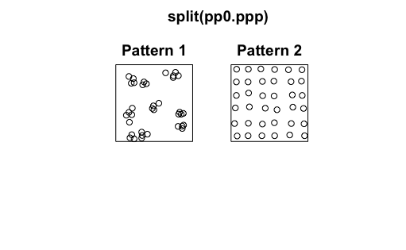

```r
plot(split(pp0.ppp))
```

These two patterns look quite different. And yet, when we count the events by quadrats:

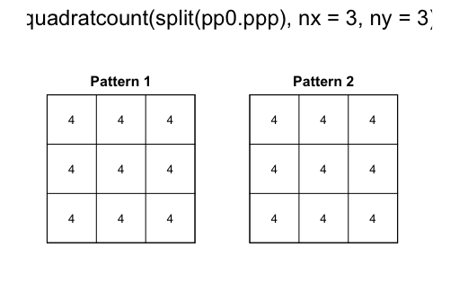

```r
plot(quadratcount(split(pp0.ppp), nx = 3, ny = 3))
```

This example highlights how quadrats are relatively coarse measures of density, and fail to distinguish between fairly different event distributions, in particular because quadrat analysis does not take into account the relative position of the events with respect to each other.

## Kernel Density

In order to better take into account the relative position of the events with respect to each other, a different technique can be devised.

Imagine that a quadrat is a kind of “window”. We use it to observe the landscape. When we count the number of events in a quadrat, we simply peek through that particular window: all events inside the “window” are simply counted, and all events outside the “window” are ignored. Then we visit another quadrat and do the same, until we have visited all quadrats.

Imagine now that we define a window that, unlike the quadrats which are fixed, can move and visit different points in space. This window also has the property that, instead of counting the events that are in the window, it gives greater weight to events that are close to the center of the window, and less weight to events that are more distant from the center of the window.

We can define such a window by selecting a function that declines with increasing distance. We will call this function a *kernel*. An example of a function that can work as a moving window is the following.

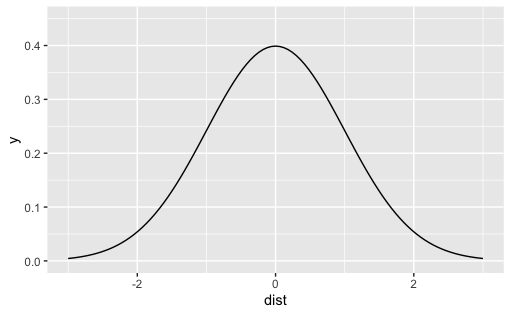

```r
ggplot(data = data.frame(dist = c(-3, 3)), aes(dist)) +
  stat_function(fun = dnorm, n = 101, args = list(mean = 0, sd = 1)) +
  ylim(c(0, 0.45))
```

As you can see, the value of the function declines with increasing distance from the center of the window (when dist == 0; note that the value never becomes zero!). This is a *Gaussian kernel*. The shape of the Gaussian kernel depends on a variance parameter, which we will call the *kernel bandwidth*.

The bandwidth controls how rapidly the weight assigned to distant events decays. Change the value of the argument `sd` in the chunk above. You will see that as it becomes smaller, the slope of the kernel becomes steeper (and distant observations are downweighted rapidly). On the contrary, as it becomes larger, the slope becomes less steep (and distant events are weighted almost as highly as close events).

Kernel density estimates are usually obtained by creating a fine grid that is superimposed on the region. The kernel function then visits each point on the grid and obtains an estimate of the density by summing the weights of all events as per the kernel function.

Kernel density is implemented in `spatstat` and can be used as follows.

The input is a `ppp` object, and optionally a `sigma` argument that corresponds to the bandwidth of the kernel:

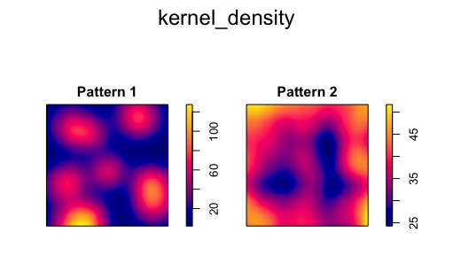

```r
kernel_density <- density(split(pp0.ppp), sigma = 0.1)
plot(kernel_density)
```

Compare to the distribution of events:

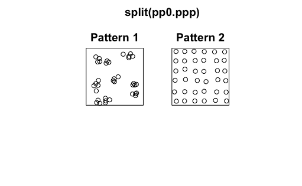

```r
plot(split(pp0.ppp))
```

The plots above illustrate how the map of the kernel density is better able to capture the variations in density across the region. In fact, kernel density is a smooth estimate of the underlying intensity of the process, and the degree of smoothing is controlled by the bandwidth.